# CSE4CG-PyOpenGL-Lab-02

## 5143135: Computer Graphics @ ZJU School of Software Technology

## Lab 2: Bezier Curves and B-Splines

Welcome to **5143135: Computer Graphics**!

After attending this lab class, you are expected to write Python programs with PyOpenGL that

- Displays 2D Cubic Bezier Curves (using formula and vector space);
- Displays 2D B-Splines (using formula and vector space).

You need **math** (Python-native) and **NumPy** (3rd-party) in this lab class. NumPy is a python library used for working with arrays. It also has functions for working in domain of linear algebra, fourier transform, and matrices. For more details about installing NumPy, please check the link below.

- https://numpy.org/install/

Before we move on, please initialize your program as follows.

```python
from OpenGL.GL import *
from OpenGL.GLUT import *
from OpenGL.GLU import *
import math                                         # Support math operations
import numpy as np                                  # Support efficient vectors and matrices


def display():
    glClear(GL_COLOR_BUFFER_BIT | GL_DEPTH_BUFFER_BIT)
    glLoadIdentity()

    glBegin(GL_LINE_LOOP)
    glColor3f(1.0, 1.0, 1.0)

    # add vertices to draw a polyline

    glEnd()

    glutSwapBuffers()


def idle():
    display()


def initRendering():
    glEnable(GL_DEPTH_TEST)
    # glEnable(GL_LIGHTING)
    # glEnable(GL_LIGHT0)


def reshape(w, h):
    glViewport(0, 0, w, h)

    glMatrixMode(GL_PROJECTION)
    glLoadIdentity()
    glOrtho(0.0, w, 0.0, h, 0.0, 1.0)

    glMatrixMode(GL_MODELVIEW)
    glLoadIdentity()


w, h = 500, 500
u, v = 100, 100

glutInit()
glutInitDisplayMode(GLUT_RGB |
                    GLUT_DOUBLE |
                    GLUT_DEPTH)

glutInitWindowSize(w, h)
glutInitWindowPosition(u, v)
glutCreateWindow("Lab 02")

initRendering()

glutReshapeFunc(reshape, w, h)
glutDisplayFunc(display)
glutIdleFunc(idle)
glutMainLoop()
```

### Task 1: 2D Cubic Bezier Curves using the Formula

As we know, a cubic Bezier curve is defined by four user-specified **control points** and their corresponding **weights** (i.e., polynomials).

Let's focus on the control points first. In Lab 1, we have learned that a 2D vertex (i.e. point) that contructs a geometry can be declared explicitly using *glVertex2f* with its float-type *x* and *y* coordinates (e.g., **glVertex2f(100.0, 100.0)**).

Alternatively, you may consider *glVertex2fv* to reach the same goal. The last postfix *v* here refers to *vector*, which means it is possible to use a vector-like object as a vertex. In Python, **NumPy** provides *arrays* for effcient vector and matrix calculation. The following codes demonstrates how to declare a vertex at (100.0, 100.0) using *glVertex2fv*.

```python
p = np.array([100.0, 100.0])                # Vertex as a NumPy array
glVertex2fv(p)
```

Does the above example remind you of using NumPy arrays for more jobs? Yes, it is also possible to create an array including multiple sub-arrays, like a 2D array in Java. For example, the *display* for Task 1 in Lab 1 can be re-written as follows.

```python
def display():

    glClear(GL_COLOR_BUFFER_BIT |
            GL_DEPTH_BUFFER_BIT)            # Remove everything from screen (i.e. displays all blank)
    glLoadIdentity()                        # Reset all objects' positions

    pts = np.array([[200, 200], [200, 300], [300, 300], [300, 200]]) # Vertices as a NumPy array

    glBegin(GL_LINE_LOOP)                   # Begin drawing
    glColor3f(1.0, 1.0, 1.0)
    glVertex2fv(pts[0])
    glVertex2fv(pts[1])
    glVertex2fv(pts[2])
    glVertex2fv(pts[3])
    glEnd()                                 # End drawing

    glutSwapBuffers()                       # Perform a buffer swap on the layer in use for the current window.
```

You can use *index*, which starts from **0**, to access an element in the array. In the above example, *pts[0]* points to the first element in the array *pts* (i.e., the first vertex). In addition, you can further access the coordinates, such as *pts[0][1]* refers to the y coordinate of the first vertex. We can store the control points in such a compact way.

Next, let's deal with the polynomials. The curve function *P(t)* has been explained in Lecture 2. Given the details, it is not difficult to define a corresponding function with Python as follows,

```python
def pBezierCurve(t, control_points):
    p = math.pow(1 - t, 3) *            control_points[0] + \
        3 * t * math.pow(1 - t, 2) *    control_points[1] + \
        3 * t * t * (1 - t) *           control_points[2] + \
        math.pow(t, 3) *                control_points[3]
    return p
```

where *t* is the parameter of the curve, and *control_points* is an array including the four control points. The returned *p* is an array storing the coordinates of the point on the curve at *t*.

We have learned that a **2D** curve can be regarded as a **1D** continuous sequence of **2D** points and approximated by tessellation. Therefore, let's try drawing a 2D cubic Bezier curve using the above function while discretizing *t* in **5** intervals. Suppose the controls points are at (200, 200), (250, 300), (300, 200), (350, 300), we modify the *display* function as follows.

```python
def display():
    pts = np.array([[200, 200],
                    [250, 300],
                    [300, 200],
                    [350, 300]])    # Control points as a NumPy array
    n = 5                           # Number of intervals for discretizing t

    glClear(GL_COLOR_BUFFER_BIT | GL_DEPTH_BUFFER_BIT)
    glLoadIdentity()

    # Draw control points
    glPointSize(5.0)                # Default point size 1.0 is too small
    glColor3f(1.0, 0.0, 0.0)        # In red

    glBegin(GL_POINTS)
    for i in range(4):
        glVertex2fv(pts[i])
    glEnd()

    glPointSize(1.0)                # Always good to reset a status

    # Draw cubic Bezier curve
    glColor3f(1.0, 1.0, 1.0)        # In white

    glBegin(GL_LINE_STRIP)
    for i in range(n + 1):
        t = i / n
        p = pBezierCurve(t, pts)
        glVertex2fv(p)
    glEnd()

    glutSwapBuffers()
```

Run the program and see if the output is the same to the following figure.

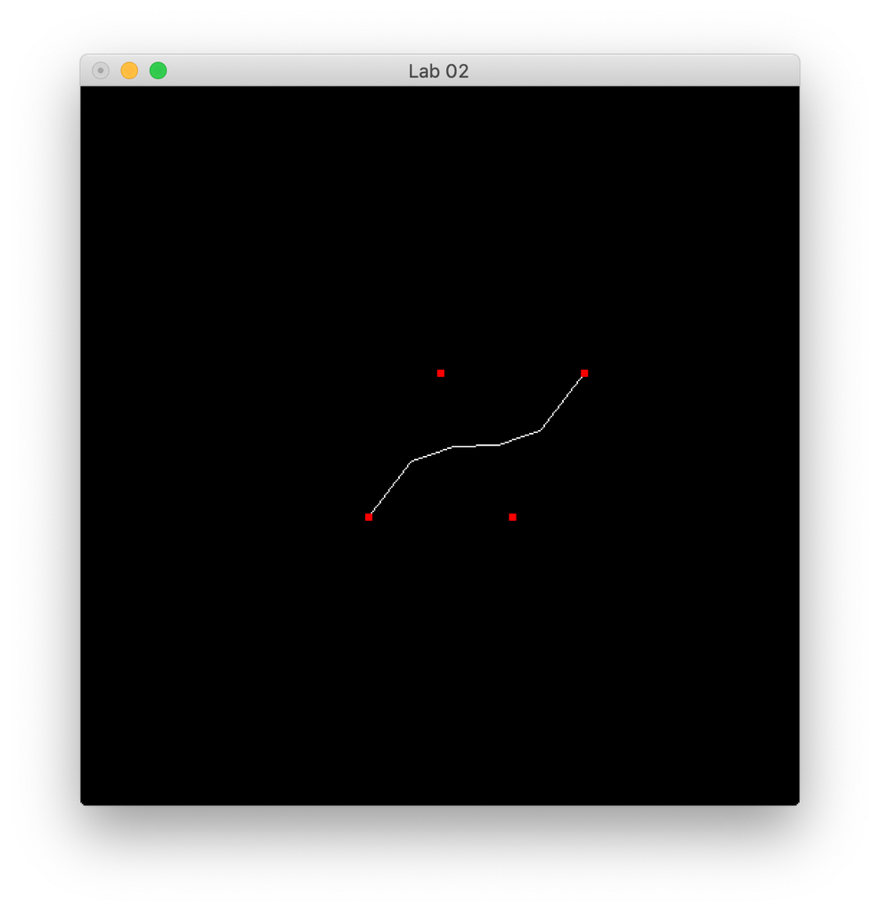

The drawn curve **interpolates** the first and the last control points, but **approximates** the other two - It satisfies the property of cubic Bezier curves!

But, don't you think this curve is not like a curve, but a polyline? In the lecture, we discussed that adding **more** points results in a polyline closer to the curve. Therefore, increase *n* to somewhat far larger than *5*, such as *100*, and there will be an obvious improvement as follows.

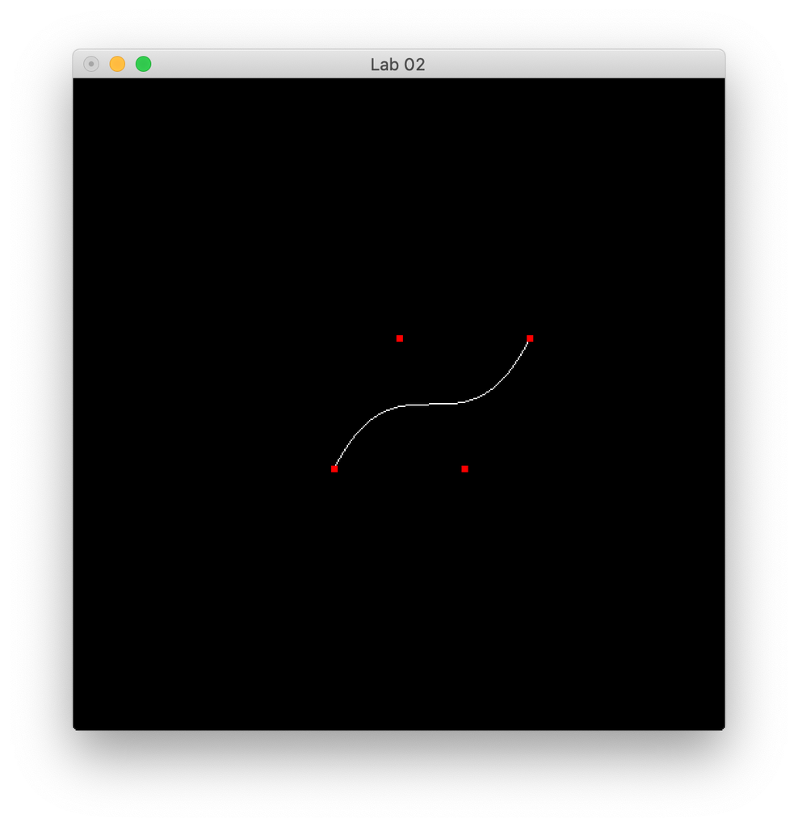

### Task 2: 2D B-Spline using a Vector Space

B-Splines are another useful kind of curves that are locally cubic. A B-Spline may have more than four control points, and is not constrained to pass through any of them. In this task, let's focus on the case where the number of control points is four.

As you will probably ask, "It's simple! Do what we just did on Bezier curves using the formula!" This indeed could be a solution as the polynomials for the control points were introduced in the lecture. Alternatively, we also introduced that a curve can be regarded as a vector space, and the **General Spline Formulation** (i.e., P(t)=**GBT**(t)) provides a decent way to solve the problem, which will be our choice in this task.

Now, let's deal with the matrices. The curve function *P(t)* has been explained in Lecture 3. Given the details, we define a corresponding function with Python as follows,

```python
def pBSpline(t, control_points):
    G = control_points.T                            # Geometry G, as the transpose of control_points
                                                    # For each point in G is a column vector

    B = np.array([  [   1, -3,  3,  -1  ],          # Spline Basis B
                    [   4,  0,  -6, 3   ],
                    [   1,  3,  3,  -3  ],
                    [   0,  0,  0,  1   ]   ]) / 6  # Don't forget to multiply a scalar 1/6

    T = np.array([  [   1           ],              # Power Basis T(t)
                    [   t           ],              # Pay attention that this a column vector
                    [   t * t       ],              # np.array([1, t, t * t, t * t * t]) is a row vector
                    [   t * t * t   ]       ])      # Row vector cannot be used here

    p = np.matmul(G, np.matmul(B, T))               # Matrix multiplication, always do it on the left
    return p
```

where t is the parameter of the curve, and control_points is an array including the four control points. The returned p is an array storing the coordinates of the point on the curve at t. **Please pay special attention to the creation of either a column vector, or a row vector.**

Suppose the controls points are same to those in Task 1, we modify the display function as follows.

```python
def display():
    pts = np.array([[200, 200],
                    [250, 300],
                    [300, 200],
                    [350, 300]])    # Control points as a NumPy array
    n = 100                         # Number of intervals for discretizing t

    glClear(GL_COLOR_BUFFER_BIT | GL_DEPTH_BUFFER_BIT)
    glLoadIdentity()

    # Draw control points
    glPointSize(5.0)                # Default point size 1.0 is too small
    glColor3f(1.0, 0.0, 0.0)        # In red

    glBegin(GL_POINTS)
    for i in range(4):
        glVertex2fv(pts[i])
    glEnd()

    glPointSize(1.0)                # Always good to reset a status

    # Draw B-Spline
    glColor3f(1.0, 1.0, 1.0)        # In white

    glBegin(GL_LINE_STRIP)
    for i in range(n + 1):
        t = i / n
        p = pBSpline(t, pts)
        glVertex2fv(p)
    glEnd()

    glutSwapBuffers()
```

Run the program and see if the output is the same to the following figure.

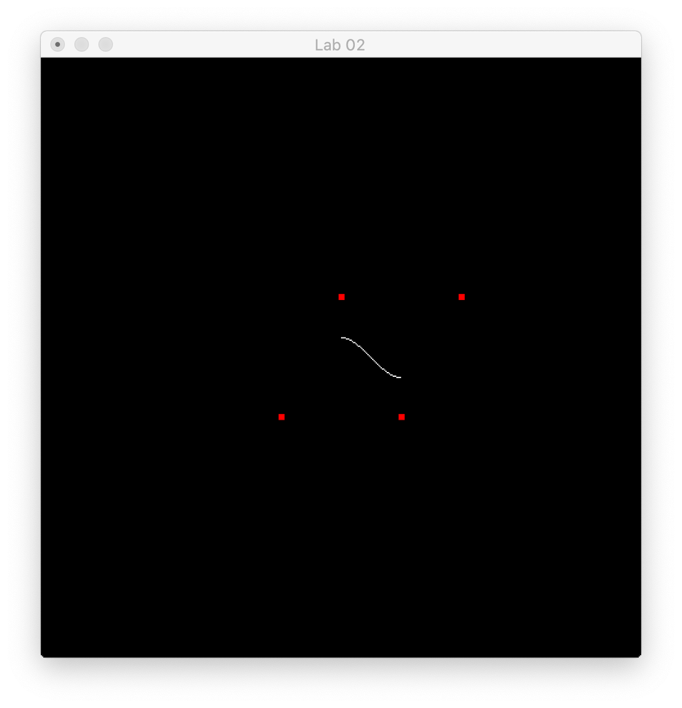

The drawn curve **approximates** all four control points, and satisfies the property of B-Splines! But this example is very limited for only four control points were considered. We emphasized at the beginning of this task that a B-Spline may have more control points. In this case, it equals that multiple cubics are **chained** together. Specifically, **every four consecutive control points contribute to a part of the entire B-Spline.**

Suppose now we have *eight* control points, the display function should be revised as follows.

```python
def display():
    pts = np.array([    [100, 200],
                        [150, 300],
                        [200, 200],
                        [250, 300],
                        [300, 200],
                        [350, 300],
                        [400, 200],
                        [450, 300]  ])    # Control points as a NumPy array
    c = 8                                 # Number of control points, 8
    n = 100                               # Number of intervals for discretizing t

    glClear(GL_COLOR_BUFFER_BIT | GL_DEPTH_BUFFER_BIT)
    glLoadIdentity()

    # Draw control points
    glPointSize(5.0)                # Default point size 1.0 is too small
    glColor3f(1.0, 0.0, 0.0)        # In red

    glBegin(GL_POINTS)
    for i in range(c):              # Change 4 to the actual number of control points
        glVertex2fv(pts[i])
    glEnd()

    glPointSize(1.0)                # Always good to reset a status

    # Draw B-Spline
    glColor3f(1.0, 1.0, 1.0)        # In white

    glBegin(GL_LINE_STRIP)
    for s in range(c - 4 + 1):      # For every 4 consecutive control points
        cp = pts[s:s+4]             # Get them from pts
        for i in range(n + 1):      # Draw their part
            t = i / n
            p = pBSpline(t, cp)     # Change pts to cp
            glVertex2fv(p)
    glEnd()

    glutSwapBuffers()
```

Run the program and see if the output is the same to the following figure.

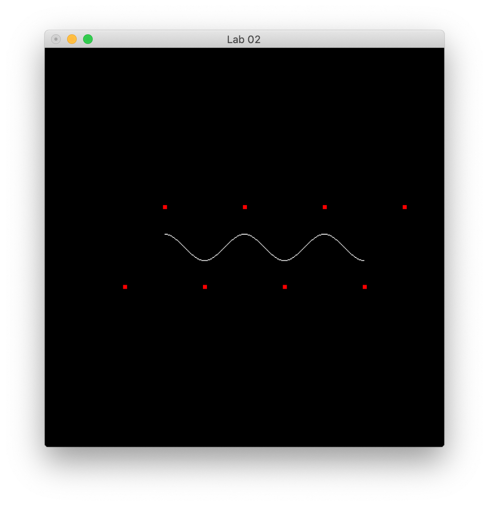

### Questions

#### Q1: Write a Python program with PyOpenGL to modify Task 1, displaying a cubic Bezier Curve using a vector space.

- Think about how Task 2 was accomplished.

#### Q2: Write a Python program with PyOpenGL to display a Bezier Curve with the 8 control points in Task 2.

- Think about the difference between Bezier Curves and B-Splines regarding the chaining of cubics.
- Hint: The number of control points **actually used** in a Bezier Curve is m*3+1, where m>0.

#### A sample solution is to be provided after the lab on the DingTalk group :)